# Lilach Ben Tov - Task

Importing the data sets:

```r
Exposure<-read.csv(file="files/Exposure_file2.csv",header=TRUE, sep=",")
Claims<-read.csv(file="files/Claims_file.csv",header=TRUE, sep=",", )
```

## Step 1 - Data preprocessing

Checking for missing values and validating data.

### Preprocessing Exposure Table

```r
class(Exposure)
```

```
## [1] "data.frame"
```

```r
dim(Exposure)
```

```
## [1] 250000      7
```

```r
summary(Exposure)
```

```
##        ID           SMOKER                    OCCUPATION
##  Min.   :     1   Mode :logical   BLUE_COLLAR      : 74934
##  1st Qu.: 62501   FALSE:174994    HEAVY_BLUE_COLLAR: 25095
##  Median :125000   TRUE :75006     WHITE_COLLAR     :149971
##  Mean   :125000
##  3rd Qu.:187500
##  Max.   :250000
##
##          DOB          POLICY_START_DATE    POLICY_END_DATE
##  8/7/1982  :    42   10/29/2011:    97   10/1/2018 :    39
##  11/19/1979:    40   7/25/2009 :    97   7/23/2018 :    38
##  5/27/1982 :    40   9/19/2011 :    97   4/28/2017 :    37
##  11/1/1980 :    39   11/16/2010:    96   1/10/2017 :    36
##  3/9/1969  :    38   6/29/2017 :    96   10/20/2018:    36
##  9/19/1989 :    38   3/6/2012  :    93   (Other)   : 44433
##  (Other)   :249763   (Other)   :249424   NA's      :205381
##  TOTAL_PREMIUM_PAID_TO_DATE
##  Min.   :  0.0
##  1st Qu.:143.4
##  Median :302.0
##  Mean   :322.0
##  3rd Qu.:488.0
##  Max.   :730.4
##
```

```r
sapply(Exposure,class)
```

```
##                         ID                     SMOKER
##                  "integer"                  "logical"
##                 OCCUPATION                        DOB
##                   "factor"                   "factor"
##          POLICY_START_DATE            POLICY_END_DATE
##                   "factor"                   "factor"
## TOTAL_PREMIUM_PAID_TO_DATE
##                  "numeric"
```

```r
Exposure[,4]<-as.Date(Exposure[,4],format=c("%m/%d/%Y"))
Exposure[,5]<-as.Date(Exposure[,5],format=c("%m/%d/%Y"))
Exposure[,6]<-as.Date(Exposure[,6],format=c("%m/%d/%Y"))
```

Validate the change

```r
summary(Exposure)
```

```
##        ID           SMOKER                    OCCUPATION
##  Min.   :     1   Mode :logical   BLUE_COLLAR      : 74934
##  1st Qu.: 62501   FALSE:174994    HEAVY_BLUE_COLLAR: 25095
##  Median :125000   TRUE :75006     WHITE_COLLAR     :149971
##  Mean   :125000
##  3rd Qu.:187500
##  Max.   :250000
##
##       DOB             POLICY_START_DATE    POLICY_END_DATE
##  Min.   :1958-12-27   Min.   :2008-11-30   Min.   :2009-02-20
##  1st Qu.:1971-12-03   1st Qu.:2011-06-02   1st Qu.:2013-12-31
##  Median :1979-11-27   Median :2013-11-29   Median :2015-12-24
##  Mean   :1979-11-28   Mean   :2013-11-29   Mean   :2015-08-06
##  3rd Qu.:1987-11-28   3rd Qu.:2016-06-01   3rd Qu.:2017-07-12
##  Max.   :2000-11-19   Max.   :2018-11-30   Max.   :2018-10-31
##                                            NA's   :205381
##  TOTAL_PREMIUM_PAID_TO_DATE
##  Min.   :  0.0
##  1st Qu.:143.4
##  Median :302.0
##  Mean   :322.0
##  3rd Qu.:488.0
##  Max.   :730.4
##
```

```r
sapply(Exposure,class)
```

```
##                         ID                     SMOKER
##                  "integer"                  "logical"
##                 OCCUPATION                        DOB
##                   "factor"                     "Date"
##          POLICY_START_DATE            POLICY_END_DATE
##                     "Date"                     "Date"
## TOTAL_PREMIUM_PAID_TO_DATE
##                  "numeric"
```

I wrote a utility function that iterates over a data frame and returns columns with missing data

```r
NAfunction<-function(x){
  dim2<-dim(x)[2]
  vec<-rep.int(0,dim(x)[2])
  for (i in 1:dim2){
    if (anyNA(Exposure[,i])==TRUE){
      vec[i]<-1
      i<-i+1
    }else
      i<-i+1

  }
  return(colnames(x[which(vec>0)]))
}
```

Running the function on the data frame:

```r
NAfunction(Exposure)
```

```
## [1] "POLICY_END_DATE"
```

As expected, only the sixth column has NA values

Removal of duplicate rows (if there any):

```r
CleanExposure<-unique(Exposure)
```

### Preprocessing Claims Table

```r
class(Claims)
```

```
## [1] "data.frame"
```

```r
dim(Claims)
```

```
## [1] 11589     3
```

```r
summary(Claims)
```

```
##        ID           CLAIM_SIZE         CLAIM_DATE
##  Min.   :     6   Min.   : 3608   20/03/2018:   18
##  1st Qu.: 62502   1st Qu.: 4211   23/04/2018:   18
##  Median :125674   Median : 4784   22/05/2017:   17
##  Mean   :124708   Mean   : 7776   25/04/2017:   17
##  3rd Qu.:186548   3rd Qu.: 5390   31/10/2018:   17
##  Max.   :249975   Max.   :21648   02/06/2018:   16
##                                   (Other)   :11486
```

```r
sapply(Claims,class)
```

```
##         ID CLAIM_SIZE CLAIM_DATE
##  "integer"  "numeric"   "factor"
```

Defining the third column class as type *date*

```r
Claims[,3]<-as.Date(Claims[,3],format=c("%d/%m/%Y"))
```

Validate the change

```r
summary(Claims)
```

```
##        ID           CLAIM_SIZE      CLAIM_DATE
##  Min.   :     6   Min.   : 3608   Min.   :2009-06-19
##  1st Qu.: 62502   1st Qu.: 4211   1st Qu.:2014-11-01
##  Median :125674   Median : 4784   Median :2016-07-18
##  Mean   :124708   Mean   : 7776   Mean   :2016-02-17
##  3rd Qu.:186548   3rd Qu.: 5390   3rd Qu.:2017-10-20
##  Max.   :249975   Max.   :21648   Max.   :2018-10-31
```

```r
sapply(Claims,class)
```

```
##         ID CLAIM_SIZE CLAIM_DATE
##  "integer"  "numeric"     "Date"
```

Looking for NA columns:

```r
NAfunction(Claims)
```

```
## character(0)
```

As expected, no missing data

Removal of duplicate rows (if there any):

```r
CleanClaims<-unique(Claims)
```

## Adding new column **age** -> calculate the user age based on the date of birth

```r
CleanExposure[,8]<-age_calc(CleanExposure$DOB,units="years",precise=FALSE)
colnames(CleanExposure)[8]<-"Age"
```

## adding new column **duration of being insured**: -> calculates the duration of being insured

```r
CleanExposure[is.na(CleanExposure$POLICY_END_DATE),6]<-as.Date('2018-12-01')
CleanExposure[,9]<-age_calc(CleanExposure$POLICY_START_DATE,enddate=as.Date(CleanExposure$POLICY_END_DATE),units="years", precise=FALSE)
colnames(CleanExposure)[9]<-"Duration_by_years"

CleanExposure[,6]<-as.Date(Exposure[,6],format=c("%d/%m/%Y"))
CleanExposure[,9]<-as.integer(CleanExposure[,9])
```

## Run SQL Queries

Create a table **SumClaims** that caluclates the number of claims and claim size per user id.

Createing a table **SumData** that joins **SumClaims** table and the **Exposure** table by user id and calculates the profit by user id

```r
SumClaims<-sqldf("select ID, sum(CLAIM_SIZE) AS CLAIM_SIZE, COUNT(*) AS NUMBER_OF_CLAIMS
 FROM CleanClaims group by 1 ")

SumData<-sqldf("select E.*, (C.CLAIM_SIZE), (C.NUMBER_OF_CLAIMS),
(case when C.CLAIM_SIZE is null then E.TOTAL_PREMIUM_PAID_TO_DATE else E.TOTAL_PREMIUM_PAID_TO_DATE-C.CLAIM_SIZE END) AS PROFIT
FROM CleanExposure E left join SumClaims C on E.ID=C.ID ")
```

## Adding new column **Margin** -> profit / revenue

```r
SumData[,13]<-SumData[,12]/SumData[,7]
colnames(SumData)[13]<-"Margin"
```

Since there is no revenue for users that started the insurance policy at the 30-11-2018 I removed those users

```r
SumData<-SumData[c(SumData$TOTAL_PREMIUM_PAID_TO_DATE>0),]
```

Setting users that didn’t submit a claim (null value) to 0

```r
SumData$NUMBER_OF_CLAIMS = ifelse(is.na(SumData$NUMBER_OF_CLAIMS), 0, SumData$NUMBER_OF_CLAIMS)

SumData$CLAIM_SIZE = ifelse(is.na(SumData$CLAIM_SIZE), 0, SumData$CLAIM_SIZE)
```

## Step 2 - Build Regression model

### Build multiple regression model:

```r
dataset<-SumData[,c(2,3,8,9,13)]
```

### Encoding categorical data

```r
dataset<-SumData[,c(2,3,8,9,13)]
dataset$SMOKER = factor(dataset$SMOKER,
                       levels = c('FALSE','TRUE'),
                       labels = c(0,1))
dataset$OCCUPATION = factor(dataset$OCCUPATION,
                        levels = c('BLUE_COLLAR','HEAVY_BLUE_COLLAR', 'WHITE_COLLAR' ),
                        labels = c(1,2,3))
```

### Feature Scaling (Age and duration)

```r
dataset[,3:4] = scale(dataset[,3:4])
```

### Fitting Multiple Linear Regression

```r
regressor = lm(formula = Margin ~ . ,
               data = dataset)

summary(regressor)
```

```
##
## Call:
## lm(formula = Margin ~ ., data = dataset)
##
## Residuals:
##      Min       1Q   Median       3Q      Max
## -1208.39     0.20     1.08     1.96     4.72
##
## Coefficients:
##                   Estimate Std. Error t value Pr(>|t|)
## (Intercept)       -1.13734    0.04404 -25.823   <2e-16 ***
## SMOKER1           -0.02353    0.04958  -0.475    0.635
## OCCUPATION2       -0.07714    0.08285  -0.931    0.352
## OCCUPATION3        1.60635    0.05082  31.608   <2e-16 ***
## Age               -0.73359    0.02348 -31.244   <2e-16 ***
## Duration_by_years  0.70092    0.02348  29.853   <2e-16 ***
## ---
## Signif. codes:  0 '***' 0.001 '**' 0.01 '*' 0.05 '.' 0.1 ' ' 1
##
## Residual standard error: 11.36 on 249923 degrees of freedom
## Multiple R-squared:  0.01075,    Adjusted R-squared:  0.01073
## F-statistic: 542.9 on 5 and 249923 DF,  p-value: < 2.2e-16
```

## Step 3 - Based on the analysis checking each parameter individually

### Checking the OCCUPATION parameter:

```r
SumData<-as.data.table(SumData)

Occupation_table<-sqldf("select OCCUPATION, sum(Margin) as Sum_Margin, avg(Margin) as mean_Margin, (avg(Margin*Margin)-avg(Margin)*Avg(Margin)) as Variance
                        from SumData group by 1 ")

Occupation_table
```

```
##          OCCUPATION Sum_Margin mean_Margin  Variance
## 1       BLUE_COLLAR  -85527.24  -1.1416876 348.91768
## 2 HEAVY_BLUE_COLLAR  -30562.79  -1.2181750 107.98160
## 3      WHITE_COLLAR   68970.87   0.4600297  23.93252
```

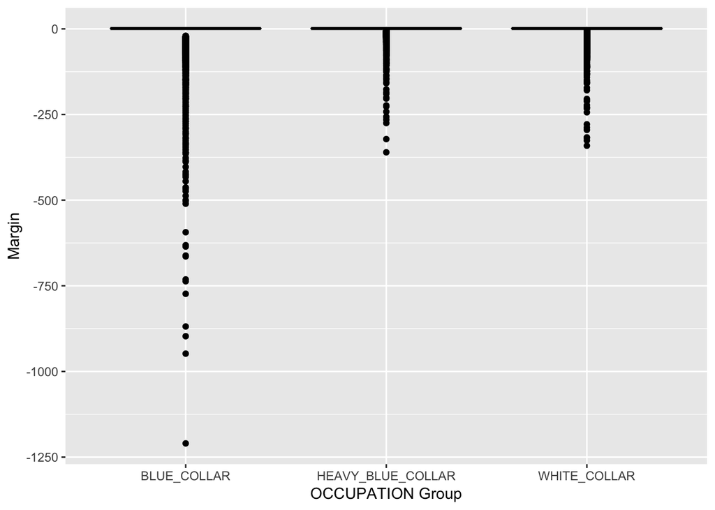

```r
ggplot(SumData, aes(x = OCCUPATION, y = Margin)) +
  geom_boxplot(fill = "grey80", colour = "black") +
  scale_x_discrete() + xlab("OCCUPATION Group") +
  ylab("Margin")
```

### Analysis conculsations

The mean margin is much higher for WHITE_COLLAR and Variance significantly small (imply for less cost claims).

### Checking the age parameter:

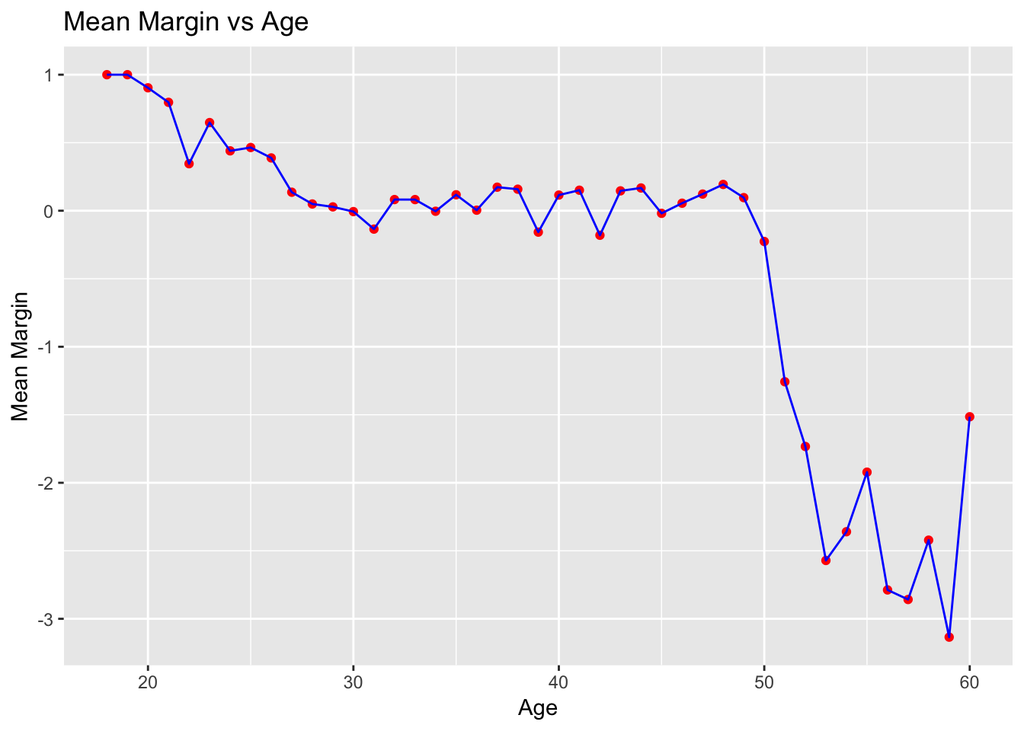

```r
Age_table<-sqldf("select Age, sum(Margin) as Sum_Margin, avg(Margin) as mean_Margin, (avg(Margin*Margin)-avg(Margin)*Avg(Margin)) as Variance,
                       sum(NUMBER_OF_CLAIMS) as NUMBER_OF_CLAIMS, count(*), sum(NUMBER_OF_CLAIMS)/count(*)*100 as percentage from SumData group by 1 ")

ggplot() +
  geom_point(aes(x = Age_table$Age, y = Age_table$mean_Margin),
             colour = 'red') +
  geom_line(aes(x = Age_table$Age, y = Age_table$mean_Margin),
            colour = 'blue') +
  ggtitle('Mean Margin vs Age') +
  xlab('Age') +
  ylab('Mean Margin')
```

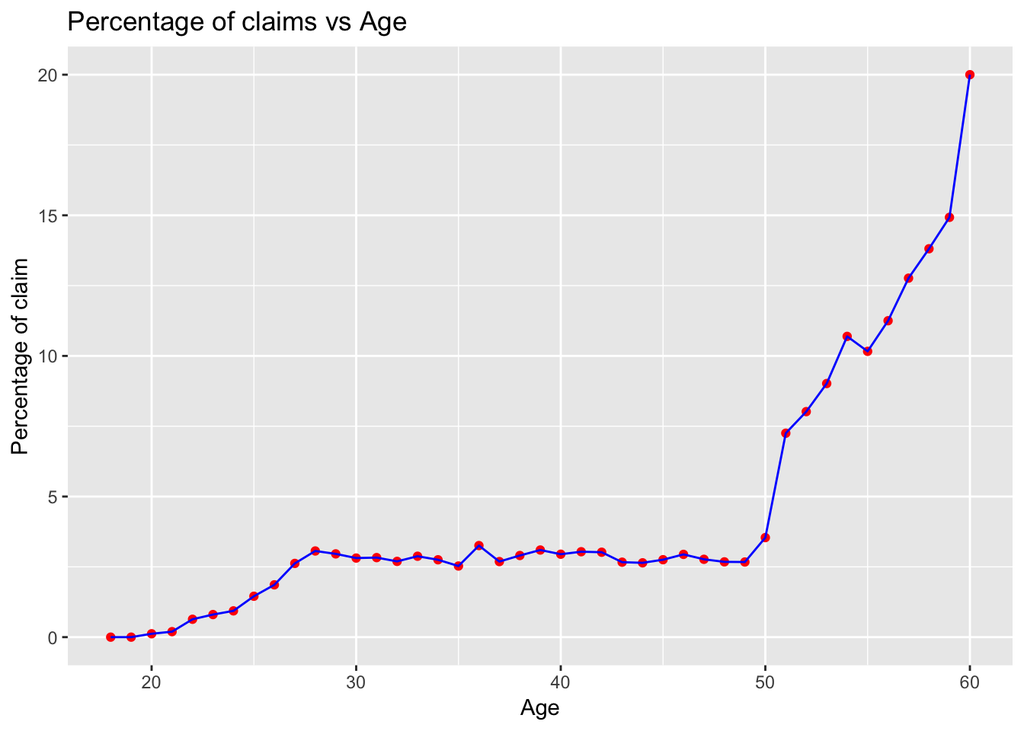

```r
ggplot() +
  geom_point(aes(x = Age_table$Age, y = Age_table$percentage),
             colour = 'red') +
  geom_line(aes(x = Age_table$Age, y = Age_table$percentage),
            colour = 'blue') +
  ggtitle('Percentage of claims vs Age') +
  xlab('Age') +
  ylab('Percentage of claim')
```

### Analysis conculsations

There is a decrease in the margin starting at the age of 50 up to the age of 60. We can see a jump above the age of 60 but that might be related to the fact that we had only 4 customers in our data. There is a significant increase in the percentage of claims from age 50 and above.

### Checking the duration:

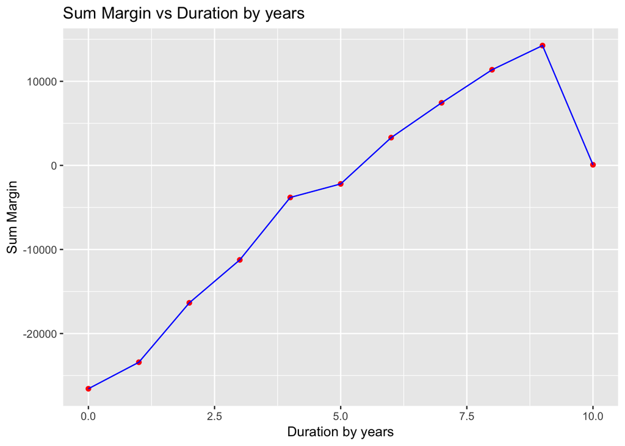

```r
Duration_table<-sqldf("select Duration_by_years, sum(Margin) as Sum_Margin,
avg(Margin) as mean_Margin,
(avg(Margin*Margin)-avg(Margin)*Avg(Margin)) as Variance,
sum(NUMBER_OF_CLAIMS) as NUMBER_OF_CLAIMS, count(*), sum(NUMBER_OF_CLAIMS)/count(*)*100 as percentage
                 from SumData group by 1 ")


ggplot() +
  geom_point(aes(x = Duration_table$Duration_by_years, y = Duration_table$Sum_Margin),
             colour = 'red') +
  geom_line(aes(x = Duration_table$Duration_by_years, y = Duration_table$Sum_Margin),
            colour = 'blue') +
  ggtitle('Sum Margin vs Duration by years ') +
  xlab('Duration by years') +
  ylab('Sum Margin')
```

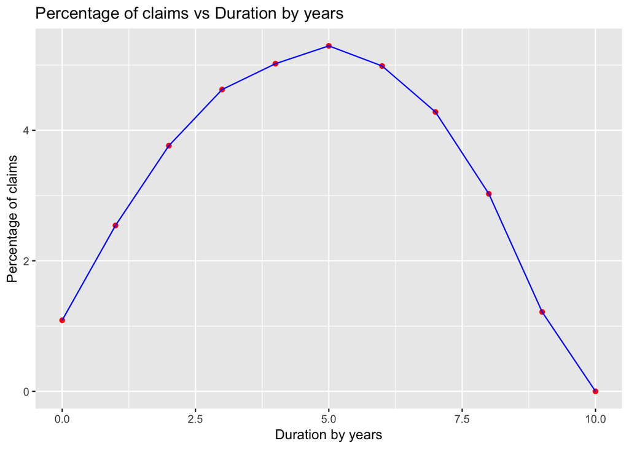

```r
ggplot() +
  geom_point(aes(x = Duration_table$Duration_by_years, y = Duration_table$percentage),
             colour = 'red') +
  geom_line(aes(x = Duration_table$Duration_by_years, y = Duration_table$percentage),
            colour = 'blue') +
  ggtitle('Percentage of claims vs Duration by years') +
  xlab('Duration by years') +
  ylab('Percentage of claims')
```

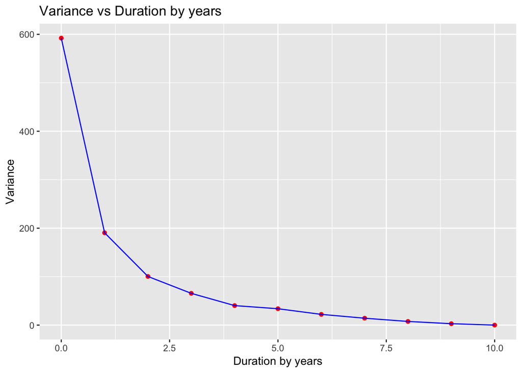

```r
ggplot() +
  geom_point(aes(x = Duration_table$Duration_by_years, y = Duration_table$Variance),
             colour = 'red') +
  geom_line(aes(x = Duration_table$Duration_by_years, y = Duration_table$Variance),
            colour = 'blue') +
  ggtitle('Variance vs Duration by years') +
  xlab('Duration by years') +
  ylab('Variance')
```

## Step 4 - Test conclusions:

### questions 1

The most profitable costumer was mesured by the margin (= profit/revenue). By using the multiple regression results and following the charts I created we can see the following that the occupation WHITE_COLLAR has significant and positive impact on margin. In addition, the WHITE_COLLAR occupation’s mean margin and the total margin are positive and the variance is signnificantly small while the two others occupations mean marin and total margin are negative and it’s variance is high. Therefore, the WHITE_COLLAR customers are the most profitable type of customer.

### questions 2

The most risky customers were measured by their number of complaints. The results show that people above the age of 50 are much more risky for the company.